# MY-DATA607-Week06-Project2-Convoys

Michael Y.

October 7, 2018

## Week 6 - Project 2 - Dataset 1: Military Convoys in WWII

```r
##setwd("c:/users/Michael/DROPBOX/priv/CUNY/MSDS/201809-Fall/DATA607_Andy_Sabrina/Week06-Project 2")
```

### The assignment is as follows:

#### Choose any three of the “wide” datasets identified in the Week 6 [sic] Discussion items.

#### For each of the three chosen datasets:

#### (1) Create a .CSV file (or optionally, a MySQL database!) that includes all of the information above. You’re encouraged to use a “wide” structure similar to how the information appears above, so that you can practice tidying and transformations as described below.

Note: For reasons explained below, I am loading multiple (eight) tables from the web. It is easier to do this by putting each table into an individual Excel sheet, where all the sheets are joined together in an Excel Workbook, rather than in 8 separate .csv files .

#### (2) Read the information from your .CSV file into R, and use `tidyr` and `dplyr` as needed to tidy and transform your data.

#### (3) Perform analysis

#### (4) Your code should be in an R Markdown file, posted to rpubs.com, and should include narrative descriptions of your data cleanup work, analysis, and conclusions.

```r
library(readr)
library(stringr)
library(tidyr)
library(dplyr)
```

```r
library(tibble)
library(ggplot2)
library(utils)
library(scales)
```

## Data Loading

#### Load the raw datafile :

The data comes from the following webpage, as suggested by Romerl:  
https://en.wikipedia.org/wiki/List_of_Allied_convoys_during_World_War_II_by_region

This webpage contains eight tables, each corresponding to a different part of the globe.

Because we have not yet covered web scraping, I don’t know how to read and parse the 8 tables directly from the Wikipedia page. So, instead I used functionality available within Excel to extract each of the 8 tables into a separate sheet within an Excel workbook. I have loaded this excel workbook into my github, from which it can be extracted as below.

I then loaded these 8 tables into R using library `XLConnect`, where they form a list of 8 dataframes.

I then proceed to perform the data cleanup, merging, etc., from this point.

While it would have been possible to write each of the eight tables back into an individual .csv file and then read each back in to R, that would create excess messiness. As given, the tables can’t be put into an individual .csv because the headers are not identical (specifically, the second column, which details the convoy routes, is region-specific.)

#### Military convoy tables (suggested by Romerl)

```r
#setwd("C:/Users/Michael/Dropbox/priv/CUNY/MSDS/201809-Fall/DATA607_Andy_Sabrina/Week06-Project 2/Convoys")


### The excel workbook "EightConvoys.xlsx" contains 8 sheets, each of which is a table from the URL listing military convoys
### https://en.wikipedia.org/wiki/List_of_Allied_convoys_during_World_War_II_by_region
```

There are 8 tables in the Wikipedia page, which are named as follows:

```r
ConvoyTableNames <- c(
  '01-European Coastal Atlantic Convoys',
  '02-North Atlantic Convoys',
  '03-North American Coastal and Caribbean Convoys',
  '04-Mediterranean and North African Coastal Convoys',
  '05-South Atlantic Convoys',
  '06-Indian Ocean Convoys',
  '07-Pacific Convoys',
  '08-Normandy Invasion Convoys'
)
```

#### Use the library “XLConnect” to load up the Excel workbook into R, creating a separate dataframe for each of the 8 tables

```r
### The package "XLConnect" easily loads up an Excel Workbook with multiple sheets, putting each sheet into a dataframe, and returning a list contains all such dfs

### If the package "XLConnect" is not already installed on this computer, then install it
if (is.na(installed.packages()[,"Package"]["XLConnect"])) {
  install.packages("XLConnect")
}

### load the library XLConnect
require(XLConnect)
```

#### Read the excel workbook into R using **loadWorkbook** from `XLConnect` .

#### Note that the Excel sheets are initially named Sheet1, Sheet2, … Sheet8 .

```r
### if loading the file from my local machine:
### wb <- loadWorkbook("Convoys/EightConvoys.xlsx")

### If retrieving the files from my Github:

sourcefile = "https://raw.githubusercontent.com/myampol/MY607/master/EightConvoys.xlsx"
destfile = "c:/temp/EightConvoys.xlsx"
download.file(sourcefile,destfile,mode="wb")

### load the entire  Excel workbook into R
wb <- loadWorkbook(destfile)
```

#### Use **readWorksheet** from `XLConnect` to create a list which captures each of the 8 sheets into an individual dataframe (again, the sheets are still named Sheet1, Sheet2,…,Sheet8)

```r
lst = readWorksheet(wb, sheet = getSheets(wb))
```

### Have a look at the structure of the list

```r
str(lst)
```

```
## List of 8
##  $ Sheet1:'data.frame':  39 obs. of  6 variables:
##   ..$ Code.Prefix          : chr [1:39] "BB" "BC" "BD" "BK" ...
##   ..$ Coastal.Convoy.Routes: chr [1:39] "Belfast or River Clyde to Bristol Channel" "Bristol Channel to Bay of Biscay" "White Sea to Dikson Island" "White Sea to Kola Inlet" ...
##   ..$ First.Sailing        : chr [1:39] "1940 from Belfast - 1945 from Clyde" NA "September 1943" "Summer 1941" ...
##   ..$ Last.Sailing         : chr [1:39] "1943 from Belfast - 1945 from Clyde" NA NA NA ...
##   ..$ Number.of.Convoys    : num [1:39] NA NA NA NA NA NA NA NA NA NA ...
##   ..$ Notes                : chr [1:39] NA "outward and return convoys used same number" NA NA ...
##  $ Sheet2:'data.frame':  36 obs. of  6 variables:
##   ..$ Code.Prefix          : chr [1:36] "AT" "BHX" "CK" "CT" ...
##   ..$ North.Atlantic.Routes: chr [1:36] "United States to British Isles" "Bermuda to Liverpool" "Charleston, South Carolina to British Isles" "British Isles to Canada" ...
##   ..$ First.Sailing        : chr [1:36] "March 1942" "May 1940" "1944" "1941" ...
##   ..$ Last.Sailing         : chr [1:36] "1945" "March 1941" "1944" "1941" ...
##   ..$ Number.of.Convoys    : chr [1:36] NA "97 (# 41-137)" NA NA ...
##   ..$ Notes                : chr [1:36] "troopships" "sailed from Bermuda and merged with same number HX convoy at sea" "rarely used" "troopships" ...
##  $ Sheet3:'data.frame':  65 obs. of  6 variables:
##   ..$ Code.Prefix                                : chr [1:65] "AH" "ARG" "AW" "BS" ...
##   ..$ North.American.Coastal.and.Caribbean.Routes: chr [1:65] "Aruba to Halifax Harbour" "Boston to Argentia, Newfoundland" "Aruba to Curaçao" "Corner Brook, Newfoundland to Sydney, Nova Scotia" ...
##   ..$ First.Sailing                              : chr [1:65] "July 1942" NA NA NA ...
##   ..$ Last.Sailing                               : chr [1:65] "September 1942" NA NA NA ...
##   ..$ Number.of.Convoys                          : logi [1:65] NA NA NA NA NA NA ...
##   ..$ Notes                                      : chr [1:65] "a brief tanker series" "USN convoys" "local tanker traffic" "a brief series" ...
##  $ Sheet4:'data.frame':  73 obs. of  6 variables:
##   ..$ Code.Prefix                                   : chr [1:73] "AC" "AG" "AH" "AN" ...
##   ..$ Mediterranean.and.North.African.Coastal.Routes: chr [1:73] "Alexandria to Tobruk" "Alexandria to Greece" "Augusta, Sicily to heel of Italy" "Alexandria to Piraeus" ...
##   ..$ First.Sailing                                 : chr [1:73] "1941" "1941" "September 1943" "1940" ...
##   ..$ Last.Sailing                                  : chr [1:73] "1941" "1941" NA "1941" ...
##   ..$ Number.of.Convoys                             : logi [1:73] NA NA NA NA NA NA ...
##   ..$ Notes                                         : chr [1:73] NA NA NA NA ...
##  $ Sheet5:'data.frame':  53 obs. of  6 variables:
##   ..$ Code.Prefix          : chr [1:53] "AS" "BF" "BRN" "BT" ...
##   ..$ South.Atlantic.Routes: chr [1:53] "United States to Suez Canal" "Bahia to Freetown" "Bahia to Recife northward" "Bahia to Trinidad" ...
##   ..$ First.Sailing        : chr [1:53] "1942" "1943" "late 1942" "November 1942" ...
##   ..$ Last.Sailing         : chr [1:53] "1942" NA NA "July 1943" ...
##   ..$ Number.of.Convoys    : logi [1:53] NA NA NA NA NA NA ...
##   ..$ Notes                : chr [1:53] "via Freetown" "USN escorts" NA NA ...
##  $ Sheet6:'data.frame':  65 obs. of  6 variables:
##   ..$ Code.Prefix        : chr [1:65] "AB" "ABF" "AJ" "AK" ...
##   ..$ Indian.Ocean.Routes: chr [1:65] "Aden to Mumbai" "Aden to Mumbai" "Aden to Colombo" "Aden to Kilindini Harbour" ...
##   ..$ First.Sailing      : chr [1:65] "November 1942" NA NA NA ...
##   ..$ Last.Sailing       : chr [1:65] NA NA NA NA ...
##   ..$ Number.of.Convoys  : num [1:65] NA NA NA NA NA NA NA NA NA NA ...
##   ..$ Notes              : chr [1:65] NA "fast troopship convoys" NA NA ...
##  $ Sheet7:'data.frame':  47 obs. of  6 variables:
##   ..$ Code.Prefix      : chr [1:47] "AN" "BG" "BN" "BT" ...
##   ..$ Pacific.Routes   : chr [1:47] "Admiralty Islands to New Guinea" "Milne Bay to New Guinea (OR) Brisbane to Gladstone, Queensland" "New Britain to New Guinea" "Sydney to United States (OR) Brisbane to Townsville, Queensland" ...
##   ..$ First.Sailing    : chr [1:47] NA NA NA "1943 (Sydney to US)" ...
##   ..$ Last.Sailing     : chr [1:47] NA NA NA "1944 (Sydney to US)" ...
##   ..$ Number.of.Convoys: logi [1:47] NA NA NA NA NA NA ...
##   ..$ Notes            : chr [1:47] NA NA NA "Sydney to US were troop convoys" ...
##  $ Sheet8:'data.frame':  53 obs. of  6 variables:
##   ..$ Code.Prefix              : chr [1:53] "ATM" "BEC" "COC" "EBC" ...
##   ..$ Normandy.Invasion.Convoys: chr [1:53] "Antwerp to River Thames" "Bristol Channel to France" "Plymouth to Brittany" "Bristol Channel to France" ...
##   ..$ First.Sailing            : chr [1:53] "late 1944" "June 1944" "late 1944" "June 1944" ...
##   ..$ Last.Sailing             : chr [1:53] "1945" "October 1944" "early 1945" "October 1944" ...
##   ..$ Number.of.Convoys        : num [1:53] NA NA NA NA 1 NA NA 2 2 NA ...
##   ..$ Notes                    : chr [1:53] NA NA NA NA ...
```

## Tidy and transform the data

#### The header of the second column (*.Routes , except for the final table) in each table differs; each should correspond to the the name of the respective Convoy for that part of the world.

#### Check the listing to ensure that we haven’t gotten the above ConvoyTableNames out-of-sequence:

```r
for (i in 1:8) print(paste(ConvoyTableNames[i], "|", names(lst[[i]][2])))
```

```
## [1] "01-European Coastal Atlantic Convoys | Coastal.Convoy.Routes"
## [1] "02-North Atlantic Convoys | North.Atlantic.Routes"
## [1] "03-North American Coastal and Caribbean Convoys | North.American.Coastal.and.Caribbean.Routes"
## [1] "04-Mediterranean and North African Coastal Convoys | Mediterranean.and.North.African.Coastal.Routes"
## [1] "05-South Atlantic Convoys | South.Atlantic.Routes"
## [1] "06-Indian Ocean Convoys | Indian.Ocean.Routes"
## [1] "07-Pacific Convoys | Pacific.Routes"
## [1] "08-Normandy Invasion Convoys | Normandy.Invasion.Convoys"
```

#### The correspondence between the above pairs of names indicate that we are indeed loading up the sheets (Sheet1, Sheet2, etc.) in the correct sequence.

#### Rename the 8 dataframes to reflect which Convoy each dataframe represents:

```r
names(lst) <- ConvoyTableNames
```

#### Have a look at the head of each table:

```r
for (i in names(lst)) {
  print(i)
  print(head(lst[[i]]))
  #####print(knitr::kable(head(lst[[i]]),format="markdown"))
  print("_____________________________________________________________________")
}
```

```
## [1] "01-European Coastal Atlantic Convoys"
##   Code.Prefix                     Coastal.Convoy.Routes
## 1          BB Belfast or River Clyde to Bristol Channel
## 2          BC          Bristol Channel to Bay of Biscay
## 3          BD                White Sea to Dikson Island
## 4          BK                   White Sea to Kola Inlet
## 5         BTC           Bristol Channel to River Thames
## 6          CE       St. Helens Roads to Southend-on-Sea
##                         First.Sailing                        Last.Sailing
## 1 1940 from Belfast - 1945 from Clyde 1943 from Belfast - 1945 from Clyde
## 2                                <NA>                                <NA>
## 3                      September 1943                                <NA>
## 4                         Summer 1941                                <NA>
## 5                                1944                                1945
## 6                                <NA>                                <NA>
```

[output cut: 141 more lines]

#### We need to perform various operations on the tables before we can concatentate them together.

#### When `XLConnect` read in each table, it made nearly everything type **character**, with the exception of the column “**Number.of.Convoys**”.

#### For some tables, everything in this column was blank, so it was assigned type **logical**.

#### For some other tables, there were numerical values for a few entries, so the column was assigned type **numeric**.

#### And, one table (#02) includes entries containing parentheses, hashmarks, and hyphens, so it was loaded as type **character**:

```r
for (i in names(lst)) {
  cat(i,"\n")
  cat(str(lst[[i]]$Number.of.Convoys))
  cat(class(lst[[i]]$Number.of.Convoys),"\n")
  cat("____________________________________________________________________\n")

}
```

```
## 01-European Coastal Atlantic Convoys
##  num [1:39] NA NA NA NA NA NA NA NA NA NA ...
## numeric
## ____________________________________________________________________
## 02-North Atlantic Convoys
##  chr [1:36] NA "97 (# 41-137)" NA NA "73" "22" "92" "89" "377" "17" ...
## character
## ____________________________________________________________________
## 03-North American Coastal and Caribbean Convoys
##  logi [1:65] NA NA NA NA NA NA ...
## logical
## ____________________________________________________________________
## 04-Mediterranean and North African Coastal Convoys
##  logi [1:73] NA NA NA NA NA NA ...
## logical
## ____________________________________________________________________
## 05-South Atlantic Convoys
##  logi [1:53] NA NA NA NA NA NA ...
## logical
## ____________________________________________________________________
## 06-Indian Ocean Convoys
##  num [1:65] NA NA NA NA NA NA NA NA NA NA ...
## numeric
## ____________________________________________________________________
## 07-Pacific Convoys
##  logi [1:47] NA NA NA NA NA NA ...
## logical
## ____________________________________________________________________
## 08-Normandy Invasion Convoys
##  num [1:53] NA NA NA NA 1 NA NA 2 2 NA ...
## numeric
## ____________________________________________________________________
```

#### (1) Before we can concatenate all 8 tables together, we have to cast the above column to same data type (**character**) because we may get an error if we attempt to combine the tables without having done so because relying on R to perform the casting will only work if we start with the table containing character data and append the other tables to it – automatic casting of numeric or logical to character will succeed, but the process will fail if trying to cast character to numeric given the specific data.

#### (2) We want to add a column which identifies which of the 8 **regions** each row corresponds to, which we will do using **add_column** from `tibble`.

#### (3) Additionally, in order to combine all the various “*.Routes" columns (and, in the final table, the equivalent column named “Normandy.Invasion.Convoy”) into a single column, we need to make every table have the same header or else we will have lots of separate columns for each type of routes, which is not what we want.

#### Once the above changes are made, we can use **bind_rows** from `dplyr` to append the dataframes together. Here we do this by creating an empty dataframe called AllConvoys and then appending each table as we loop through:

```r
AllConvoys=NULL

for (df_name in names(lst)) {

  ### When each sheet was initially read in, the type assigned to Number.of.Convoys varied.
  ### We cannot append all the tables together if the type of this column is not uniform
  ### therefore, forcibly cast all such items to CHARACTER

  lst[[df_name]]$Number.of.Convoys <- as.character(lst[[df_name]]$Number.of.Convoys)


  ### expand each dataframe by inserting a "Region" column which contains the region name
  lst[[df_name]] <-   add_column(lst[[df_name]],Region=df_name,.before=1)

  ### Because we put the region name at the beginning (i.e., leftmost-column),
  ### the column containing the various Routes has shifted from column 2 to column 3.
  ### In order to aggregate all such columns together across the eight dataframes,
  ### rename them all "Routes", as the new "Region" column contains the necessary information to identify the area

  names(lst[[df_name]])[3] <- "Routes"

### concatentate all eight tables together using bind_rows
### here we're doing it one-at-a-time by appending each table onto the previous ones
### note that this would fail without the type adjustment above on Number.of.Convoys

AllConvoys <- bind_rows(AllConvoys,lst[[df_name]])

###cat("\nEnd of processing ",df_name)
}
```

#### We now have a table which contains 431 rows. Here are views of selections from the table:

```r
dim(AllConvoys)
```

```
## [1] 431   7
```

```r
head(AllConvoys)
```

```
##                                 Region Code.Prefix
## 1 01-European Coastal Atlantic Convoys          BB
## 2 01-European Coastal Atlantic Convoys          BC
## 3 01-European Coastal Atlantic Convoys          BD
## 4 01-European Coastal Atlantic Convoys          BK
## 5 01-European Coastal Atlantic Convoys         BTC
## 6 01-European Coastal Atlantic Convoys          CE
##                                      Routes
## 1 Belfast or River Clyde to Bristol Channel
## 2          Bristol Channel to Bay of Biscay
## 3                White Sea to Dikson Island
## 4                   White Sea to Kola Inlet
## 5           Bristol Channel to River Thames
## 6       St. Helens Roads to Southend-on-Sea
##                         First.Sailing                        Last.Sailing
## 1 1940 from Belfast - 1945 from Clyde 1943 from Belfast - 1945 from Clyde
## 2                                <NA>                                <NA>
## 3                      September 1943                                <NA>
## 4                         Summer 1941                                <NA>
## 5                                1944                                1945
## 6                                <NA>                                <NA>
##   Number.of.Convoys                                       Notes
## 1              <NA>                                        <NA>
## 2              <NA> outward and return convoys used same number
## 3              <NA>                                        <NA>
## 4              <NA>                                        <NA>
## 5              <NA>                                        <NA>
## 6              <NA>                                        <NA>
```

```r
tail(AllConvoys)
```

```
##                           Region Code.Prefix
## 426 08-Normandy Invasion Convoys         WEP
## 427 08-Normandy Invasion Convoys         WFM
## 428 08-Normandy Invasion Convoys         WMP
## 429 08-Normandy Invasion Convoys         WNC
## 430 08-Normandy Invasion Convoys         WNL
## 431 08-Normandy Invasion Convoys         WVP
##                                     Routes First.Sailing  Last.Sailing
## 426   Isle of Wight to Cherbourg-Octeville December 1944 December 1944
## 427                                   <NA>  October 1944 November 1944
## 428 Isle of Wight to Arromanches-les-Bains November 1944 December 1944
## 429              Isle of Wight to Le Havre December 1944      May 1945
## 430                Isle of Wight to France    April 1945      May 1945
## 431                Isle of Wight to France December 1944      May 1945
##     Number.of.Convoys            Notes
## 426              <NA>             <NA>
## 427              <NA> invasion convoys
## 428              <NA>             <NA>
## 429              <NA>             <NA>
## 430              <NA>             <NA>
## 431              <NA>             <NA>
```

```r
### Note that the below two subsetting/filtering methods select the same rows, but differ on the index numbering:
AllConvoys[seq(1,431,25),]
```

```
##                                                 Region Code.Prefix
## 1                 01-European Coastal Atlantic Convoys          BB
## 26                01-European Coastal Atlantic Convoys          NP
## 51                           02-North Atlantic Convoys          KJ
## 76     03-North American Coastal and Caribbean Convoys          AH
## 101    03-North American Coastal and Caribbean Convoys          HK
## 126    03-North American Coastal and Caribbean Convoys          SH
## 151 04-Mediterranean and North African Coastal Convoys          CG
## 176 04-Mediterranean and North African Coastal Convoys          MW
## 201 04-Mediterranean and North African Coastal Convoys         TSS
## 226                          05-South Atlantic Convoys          FB
## 251                          05-South Atlantic Convoys         STL
## 276                            06-Indian Ocean Convoys         BAF
## 301                            06-Indian Ocean Convoys          JC
## 326                            06-Indian Ocean Convoys          SR
```

[output cut: 80 more lines]

```r
filter(AllConvoys,row_number() %% 25==1)
```

```
##                                                Region Code.Prefix
## 1                01-European Coastal Atlantic Convoys          BB
## 2                01-European Coastal Atlantic Convoys          NP
## 3                           02-North Atlantic Convoys          KJ
## 4     03-North American Coastal and Caribbean Convoys          AH
## 5     03-North American Coastal and Caribbean Convoys          HK
## 6     03-North American Coastal and Caribbean Convoys          SH
## 7  04-Mediterranean and North African Coastal Convoys          CG
## 8  04-Mediterranean and North African Coastal Convoys          MW
## 9  04-Mediterranean and North African Coastal Convoys         TSS
## 10                          05-South Atlantic Convoys          FB
## 11                          05-South Atlantic Convoys         STL
## 12                            06-Indian Ocean Convoys         BAF
## 13                            06-Indian Ocean Convoys          JC
## 14                            06-Indian Ocean Convoys          SR
```

[output cut: 61 more lines]

#### Most of the Routes are of the form “Origin” to “Destination”.

#### Extract the Origin and Destination into individual columns, but retain the original route so we can examine those for which such separation fails

```r
AllConvoys <- extract(AllConvoys,
                      Routes,
                      into = c('Origin', 'Destination'),
                      '(.*)\\sto\\s(.*)',
                      remove=FALSE)

head(AllConvoys)
```

```
##                                 Region Code.Prefix
## 1 01-European Coastal Atlantic Convoys          BB
## 2 01-European Coastal Atlantic Convoys          BC
## 3 01-European Coastal Atlantic Convoys          BD
## 4 01-European Coastal Atlantic Convoys          BK
## 5 01-European Coastal Atlantic Convoys         BTC
## 6 01-European Coastal Atlantic Convoys          CE
##                                      Routes                 Origin
## 1 Belfast or River Clyde to Bristol Channel Belfast or River Clyde
## 2          Bristol Channel to Bay of Biscay        Bristol Channel
## 3                White Sea to Dikson Island              White Sea
## 4                   White Sea to Kola Inlet              White Sea
## 5           Bristol Channel to River Thames        Bristol Channel
## 6       St. Helens Roads to Southend-on-Sea       St. Helens Roads
##       Destination                       First.Sailing
```

[output cut: 20 more lines]

```r
tail(AllConvoys)
```

```
##                           Region Code.Prefix
## 426 08-Normandy Invasion Convoys         WEP
## 427 08-Normandy Invasion Convoys         WFM
## 428 08-Normandy Invasion Convoys         WMP
## 429 08-Normandy Invasion Convoys         WNC
## 430 08-Normandy Invasion Convoys         WNL
## 431 08-Normandy Invasion Convoys         WVP
##                                     Routes        Origin
## 426   Isle of Wight to Cherbourg-Octeville Isle of Wight
## 427                                   <NA>          <NA>
## 428 Isle of Wight to Arromanches-les-Bains Isle of Wight
## 429              Isle of Wight to Le Havre Isle of Wight
## 430                Isle of Wight to France Isle of Wight
## 431                Isle of Wight to France Isle of Wight
##               Destination First.Sailing  Last.Sailing Number.of.Convoys
## 426   Cherbourg-Octeville December 1944 December 1944              <NA>
## 427                  <NA>  October 1944 November 1944              <NA>
## 428 Arromanches-les-Bains November 1944 December 1944              <NA>
## 429              Le Havre December 1944      May 1945              <NA>
## 430                France    April 1945      May 1945              <NA>
## 431                France December 1944      May 1945              <NA>
##                Notes
## 426             <NA>
## 427 invasion convoys
## 428             <NA>
## 429             <NA>
## 430             <NA>
## 431             <NA>
```

#### Let’s examine those items which didn’t have " to " in the Route

```r
Failed_To_Extract <- filter(.data = AllConvoys, is.na(Origin))
Failed_To_Extract
```

```
##                                                Region Code.Prefix
## 1  04-Mediterranean and North African Coastal Convoys         ARM
## 2  04-Mediterranean and North African Coastal Convoys         CNF
## 3  04-Mediterranean and North African Coastal Convoys         NCF
## 4  04-Mediterranean and North African Coastal Convoys         NCS
## 5  04-Mediterranean and North African Coastal Convoys         SBF
## 6  04-Mediterranean and North African Coastal Convoys         SBM
## 7  04-Mediterranean and North African Coastal Convoys         TJF
## 8  04-Mediterranean and North African Coastal Convoys         TJM
## 9  04-Mediterranean and North African Coastal Convoys         TJS
## 10 04-Mediterranean and North African Coastal Convoys         TSF
## 11 04-Mediterranean and North African Coastal Convoys         TSM
## 12 04-Mediterranean and North African Coastal Convoys         TSS
## 13                          05-South Atlantic Convoys         LGE
## 14                          05-South Atlantic Convoys         LGW
```

[output cut: 73 more lines]

#### There are 21 such rows where the Route is not of the form (Origin) to (Destination).

#### There is a column “Number.of.Convoys” which lists the number of times a particular route was used. Unfortunately it is not populated for most rows. There are a few rows where the entry includes a **count** as well as additional information (apparently a range of sequence numbers, e.g., “97 (# 41-137)”).

```r
AllConvoys %>% filter(str_detect(string = Number.of.Convoys,    pattern = "\\("))
```

```
##                      Region Code.Prefix                Routes    Origin
## 1 02-North Atlantic Convoys         BHX  Bermuda to Liverpool   Bermuda
## 2 02-North Atlantic Convoys          JW  Iceland to White Sea   Iceland
## 3 02-North Atlantic Convoys          RA White Sea to Scotland White Sea
##   Destination    First.Sailing Last.Sailing Number.of.Convoys
## 1   Liverpool         May 1940   March 1941     97 (# 41-137)
## 2   White Sea 25 December 1942  12 May 1945      17 (# 51-67)
## 3    Scotland 30 December 1942  23 May 1945      17 (# 51-67)
##                                                              Notes
## 1 sailed from Bermuda and merged with same number HX convoy at sea
## 2                                              replaced PQ convoys
## 3                                              replaced QP convoys
```

#### We need to remove this extraneous detail from these items in order to be able to make any use of the counts. Additionally, we need to cast the values from character back to numeric.

```r
AllConvoys <- AllConvoys %>%
  mutate(Number.of.Convoys,
         Number.of.Convoys=as.numeric(
           gsub(pattern = " .*$",replacement = "",x=Number.of.Convoys)))
```

## Analysis

#### Plot the number of convoy routes per region:

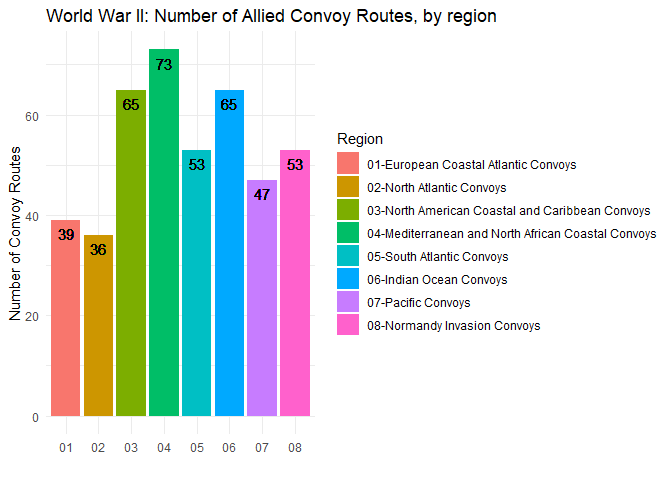

```r
AllConvoys %>%
  select(Region) %>%
  mutate(RegionNum=substr(Region,1,2)) %>%
  ggplot(aes(x=factor(RegionNum), y=table(RegionNum)[RegionNum], fill=Region)) +
  geom_bar(stat="identity", position="dodge")+
  theme_minimal()+
  geom_text(aes(label=as.integer(table(RegionNum)[RegionNum])),
            vjust=1.6, color="black",
            position = position_dodge(0.8), size=4) +
  scale_x_discrete( expand = waiver(), position = "bottom")+
  scale_y_continuous(name = waiver(), breaks = waiver(),
                     minor_breaks = waiver(), labels = waiver(), limits = NULL,
                     expand = waiver(), oob = censor, na.value = NA_real_,
                     trans = "identity", position = "left", sec.axis = waiver()) +
    labs(x="",y="Number of Convoy Routes")+
  ggtitle("World War II: Number of Allied Convoy Routes, by region")
```

#### Although there is field “Number.of.Convoys” which apparently counts the number of times a particular route was used, it is not populated for most rows. In particular, it is only populated for 33 rows out of 431.

```r
CountOfConvoysDefined <- AllConvoys %>% filter(!is.na(Number.of.Convoys)) %>% count(x = .)

Total.Number.of.Convoys <- sum(AllConvoys$Number.of.Convoys,na.rm=T)
```

#### Once the data is cleaned, the number of rows for which the Number.of.Convoys is not NA is 33 .

#### The totalsum of the number of convoys on such rows is 2842 .

#### These are such rows:

```r
AllConvoys %>% filter(!is.na(Number.of.Convoys))
```

```
##                                  Region Code.Prefix
## 1  01-European Coastal Atlantic Convoys          OA
## 2  01-European Coastal Atlantic Convoys          OB
## 3             02-North Atlantic Convoys         BHX
## 4             02-North Atlantic Convoys          CU
## 5             02-North Atlantic Convoys         GUF
## 6             02-North Atlantic Convoys         GUS
## 7             02-North Atlantic Convoys          HG
## 8             02-North Atlantic Convoys          HX
## 9             02-North Atlantic Convoys         HXF
## 10            02-North Atlantic Convoys          JW
## 11            02-North Atlantic Convoys         KMF
## 12            02-North Atlantic Convoys         KMS
## 13            02-North Atlantic Convoys         MKF
## 14            02-North Atlantic Convoys         MKS
```

[output cut: 189 more lines]

#### This sums up the Number.of.Convoys by region, where such number is not NA:

```r
TotalConvoysByRegion <- AllConvoys %>%
  group_by(Region) %>%
  summarise(total_convoys = sum(Number.of.Convoys, na.rm = T)) %>%
  ungroup()
TotalConvoysByRegion
```

```
## # A tibble: 8 x 2
##   Region                                             total_convoys
##   <chr>                                                      <dbl>
## 1 01-European Coastal Atlantic Convoys                         579
## 2 02-North Atlantic Convoys                                   2253
## 3 03-North American Coastal and Caribbean Convoys                0
## 4 04-Mediterranean and North African Coastal Convoys             0
## 5 05-South Atlantic Convoys                                      0
## 6 06-Indian Ocean Convoys                                        5
## 7 07-Pacific Convoys                                             0
## 8 08-Normandy Invasion Convoys                                   5
```

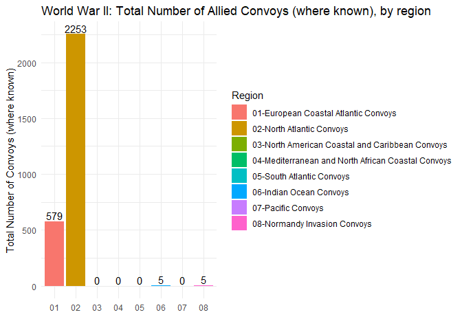

```r
TotalConvoysByRegion %>%
  mutate(RegionNum=substr(Region,1,2)) %>%
  ggplot(aes(x=factor(RegionNum), y=total_convoys, fill=Region)) +
  geom_bar(stat="identity", position="dodge")+
  theme_minimal()+
  geom_text(aes(label=total_convoys),
            vjust=-0.2, color="black",
            position = position_dodge(0.8), size=4) +
  scale_x_discrete( expand = waiver(), position = "bottom")+
  scale_y_continuous(name = waiver(), breaks = waiver(),
                     minor_breaks = waiver(), labels = waiver(), limits = NULL,
                     expand = waiver(), oob = censor, na.value = NA_real_,
                     trans = "identity", position = "left", sec.axis = waiver()) +
  labs(x="",y="Total Number of Convoys (where known)")+
  ggtitle("World War II: Total Number of Allied Convoys (where known), by region")
```

#### Convoy routes by Origin (top 10)

```r
ConvoysByOrigin <- AllConvoys %>%
  group_by(Origin) %>%
  summarise(ConvoyRoutesByOrigin = n()) %>%
  arrange(.data = ., desc(ConvoyRoutesByOrigin)) %>%
  ungroup()
top_n(x = ConvoysByOrigin, wt=ConvoyRoutesByOrigin, n = 10)
```

```
## # A tibble: 11 x 2
##    Origin          ConvoyRoutesByOrigin
##    <chr>                          <int>
##  1 <NA>                              21
##  2 Trinidad                          13
##  3 France                            11
##  4 Isle of Wight                     10
##  5 River Thames                      10
##  6 Freetown                           9
##  7 Halifax Harbour                    9
##  8 Alexandria                         8
##  9 British Isles                      8
## 10 Dakar                              8
## 11 Liverpool                          8
```

#### The above reflects the fact that there are 21 routes for which it was not possible to extract origin/destination details.

## Convoy routes by Destination (top 10)

```r
ConvoysByDestination <- AllConvoys %>%
  filter(!is.na(Destination)) %>%
  group_by(Destination) %>%
  summarise(ConvoyRoutesByDestination = n()) %>%
  arrange(.data = ., desc(ConvoyRoutesByDestination)) %>%
  ungroup()
top_n(x = ConvoysByDestination, wt=ConvoyRoutesByDestination, n = 10)
```

```
## # A tibble: 11 x 2
##    Destination               ConvoyRoutesByDestination
##    <chr>                                         <int>
##  1 France                                           19
##  2 Liverpool                                        10
##  3 Townsville, Queensland                           10
##  4 Aden                                              8
##  5 British Isles                                     8
##  6 Halifax Harbour                                   8
##  7 Guantanamo Bay Naval Base                         7
##  8 Key West, Florida                                 7
##  9 dispersal                                         6
## 10 Gibraltar                                         6
## 11 Trinidad                                          6
```

#### This example would have also shown the 21 rows for which Destination is “NA”, except I have filtered them out.

#### From above we can observe that there are a large number of Convoy routes for which the “Origin” or “Destination” is simply “France”, without further designation of a specific city/port. As it turns out, all such items are associated with the Normandy Invasion:

```r
AllConvoys %>%
  filter(Origin=="France"|Destination=="France")
```

```
##                          Region Code.Prefix                       Routes
## 1  08-Normandy Invasion Convoys         BEC    Bristol Channel to France
## 2  08-Normandy Invasion Convoys         EBC    Bristol Channel to France
## 3  08-Normandy Invasion Convoys         EBM    Bristol Channel to France
## 4  08-Normandy Invasion Convoys         ECM Falmouth, Cornwall to France
## 5  08-Normandy Invasion Convoys         EMM            Belfast to France
## 6  08-Normandy Invasion Convoys         EMP            Belfast to France
## 7  08-Normandy Invasion Convoys         ETC       River Thames to France
## 8  08-Normandy Invasion Convoys         ETM       River Thames to France
## 9  08-Normandy Invasion Convoys         EWL      Isle of Wight to France
## 10 08-Normandy Invasion Convoys         EWM      Isle of Wight to France
## 11 08-Normandy Invasion Convoys         EWP      Isle of Wight to France
## 12 08-Normandy Invasion Convoys          FC    France to western England
## 13 08-Normandy Invasion Convoys         FCP    France to western England
## 14 08-Normandy Invasion Convoys         FPM   France to Portland Harbour
```

[output cut: 78 more lines]

```r
ConvoysByOriginExInvasion <- AllConvoys %>% filter(.data = ., Region != ConvoyTableNames[8]  &  !is.na(Origin)) %>%
  group_by(Origin) %>%
  summarise(ConvoyRoutesByOrigin = n()) %>%
  arrange(.data = ., desc(ConvoyRoutesByOrigin)) %>%
  ungroup()
top_n(x = ConvoysByOriginExInvasion, wt=ConvoyRoutesByOrigin, n = 10)
```

```
## # A tibble: 10 x 2
##    Origin                    ConvoyRoutesByOrigin
##    <chr>                                    <int>
##  1 Trinidad                                    13
##  2 Freetown                                     9
##  3 Halifax Harbour                              9
##  4 Alexandria                                   8
##  5 British Isles                                8
##  6 Dakar                                        8
##  7 Liverpool                                    8
##  8 Aden                                         7
##  9 Gibraltar                                    7
## 10 Guantanamo Bay Naval Base                    7
```

```r
ConvoysByDestinationExInvasion <- AllConvoys %>% filter(.data = ., Region != ConvoyTableNames[8]  &  !is.na(Destination)) %>%
  group_by(Destination) %>%
  summarise(ConvoyRoutesByDestination = n()) %>%
  arrange(.data = ., desc(ConvoyRoutesByDestination)) %>%
  ungroup()
top_n(x = ConvoysByDestinationExInvasion, wt=ConvoyRoutesByDestination, n = 10)
```

```
## # A tibble: 10 x 2
##    Destination               ConvoyRoutesByDestination
##    <chr>                                         <int>
##  1 Liverpool                                        10
##  2 Townsville, Queensland                           10
##  3 Aden                                              8
##  4 Halifax Harbour                                   8
##  5 British Isles                                     7
##  6 Guantanamo Bay Naval Base                         7
##  7 Key West, Florida                                 7
##  8 dispersal                                         6
##  9 Gibraltar                                         6
## 10 Trinidad                                          6
```

#### We see that a sizable number of convoys are to or from Liverpool, a major U.K. port:

```r
AllConvoys %>%
  filter(Origin=="Liverpool"|Destination=="Liverpool")
```

```
##                                  Region Code.Prefix
## 1  01-European Coastal Atlantic Convoys          OA
## 2  01-European Coastal Atlantic Convoys          OB
## 3             02-North Atlantic Convoys         BHX
## 4             02-North Atlantic Convoys          CU
## 5             02-North Atlantic Convoys          HG
## 6             02-North Atlantic Convoys          HX
## 7             02-North Atlantic Convoys         HXF
## 8             02-North Atlantic Convoys         KMS
## 9             02-North Atlantic Convoys         MKS
## 10            02-North Atlantic Convoys          OG
## 11            02-North Atlantic Convoys          ON
## 12            02-North Atlantic Convoys         ONS
## 13            02-North Atlantic Convoys          OS
## 14            02-North Atlantic Convoys          SC
```

[output cut: 99 more lines]

#### And, for those routes on which we have frequency information, we see that Liverpool is well-represented at the top of the list:

```r
FrequentlyUsedConvoyRoutes <- AllConvoys %>% filter(.data = .,  !is.na(Number.of.Convoys)) %>%
  #group_by(Origin) %>%
  #summarise(ConvoyRoutesByOrigin = n()) %>%
  arrange(.data = ., desc(Number.of.Convoys)) %>%
  ungroup()
top_n(x = FrequentlyUsedConvoyRoutes, wt=Number.of.Convoys,  n = 10)
```

```
##                                  Region Code.Prefix
## 1             02-North Atlantic Convoys          HX
## 2  01-European Coastal Atlantic Convoys          OB
## 3             02-North Atlantic Convoys          ON
## 4  01-European Coastal Atlantic Convoys          OA
## 5             02-North Atlantic Convoys          SL
## 6             02-North Atlantic Convoys          SC
## 7             02-North Atlantic Convoys          OS
## 8             02-North Atlantic Convoys         MKS
## 9             02-North Atlantic Convoys         KMS
## 10            02-North Atlantic Convoys         BHX
##                                                                    Routes
## 1                      Halifax Harbour (later New York City) to Liverpool
## 2                                         Liverpool to the Atlantic Ocean
## 3                                            Liverpool to Halifax Harbour
```

[output cut: 40 more lines]

#### Aggregating, Liverpool is by far the most frequent origin:

```r
FrequentlyUsedOrigins <- AllConvoys %>% filter(.data = .,  !is.na(Number.of.Convoys)) %>%
  group_by(Origin) %>%
  summarise(total_convoys = sum(Number.of.Convoys, na.rm = T)) %>%
  arrange(.data = ., desc(total_convoys)) %>%
  ungroup()
top_n(x = FrequentlyUsedOrigins, wt=total_convoys,  n = 10)
```

```
## # A tibble: 10 x 2
##    Origin                                                    total_convoys
##    <chr>                                                             <dbl>
##  1 Liverpool                                                          1098
##  2 Halifax Harbour (later New York City)                               377
##  3 Mediterranean                                                       262
##  4 River Thames (or Methil, Fife after July 1940)                      234
##  5 Sierra Leone                                                        178
##  6 Sydney, Nova Scotia (or Halifax Harbour or New York City)           177
##  7 Chesapeake Bay                                                      117
##  8 Bermuda                                                              97
##  9 Gibraltar                                                            89
## 10 Caribbean (later New York City)                                      73
```

#### Here’s a plot of the top 10 Origins:

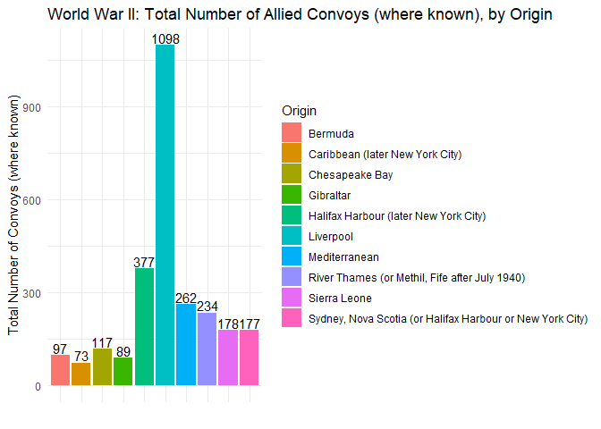

```r
FrequentlyUsedOrigins %>%
  top_n(x = ., wt=total_convoys,  n = 10) %>%
  ggplot(aes(x=Origin, y=total_convoys, fill=Origin)) +
  geom_bar(stat="identity", position="dodge")+
  theme_minimal()+
  theme(axis.text.x=element_blank())+
  geom_text(aes(label=total_convoys),
            vjust=-0.2, color="black",
            position = position_dodge(0.8), size=4) +
  scale_x_discrete( expand = waiver(), position = "bottom")+
  scale_y_continuous(name = waiver(), breaks = waiver(),
                     minor_breaks = waiver(), labels = waiver(), limits = NULL,
                     expand = waiver(), oob = censor, na.value = NA_real_,
                     trans = "identity", position = "left", sec.axis = waiver()) +
  labs(x="",y="Total Number of Convoys (where known)")+
  ggtitle("World War II: Total Number of Allied Convoys (where known), by Origin")
```

#### Similarly, Liverpool is also the most frequent destination:

```r
FrequentlyUsedDestinations <- AllConvoys %>% filter(.data = .,  !is.na(Number.of.Convoys)) %>%
  group_by(Destination) %>%
  summarise(total_convoys = sum(Number.of.Convoys, na.rm = T)) %>%
  arrange(.data = ., desc(total_convoys)) %>%
  ungroup()
top_n(x = FrequentlyUsedDestinations, wt=total_convoys,  n = 10)
```

```
## # A tibble: 10 x 2
##    Destination                     total_convoys
##    <chr>                                   <dbl>
##  1 Liverpool                                1345
##  2 Halifax Harbour                           358
##  3 the Atlantic Ocean                        345
##  4 Mediterranean                             260
##  5 Sierra Leone                              131
##  6 Chesapeake Bay                            114
##  7 Gibraltar                                  95
##  8 Caribbean (later New York City)            71
##  9 Firth of Clyde or Liverpool                45
## 10 White Sea                                  35
```

#### Here’s a plot of the top 10 Destinations:

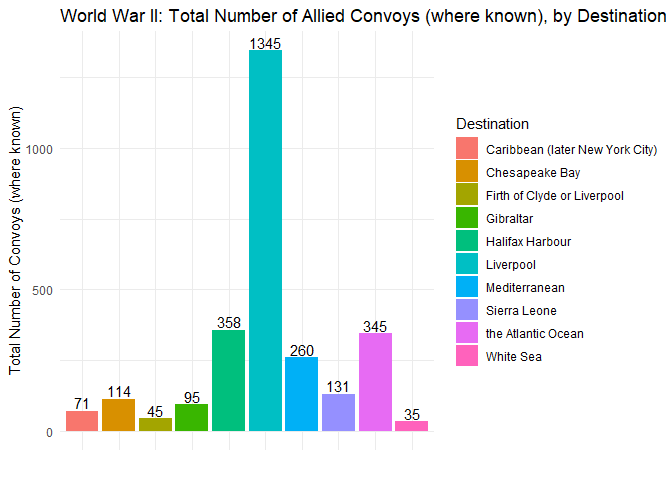

```r
FrequentlyUsedDestinations %>%
  top_n(x = ., wt=total_convoys,  n = 10) %>%
  ggplot(aes(x=Destination, y=total_convoys, fill=Destination)) +
  geom_bar(stat="identity", position="dodge")+
  theme_minimal()+
  theme(axis.text.x=element_blank())+
  geom_text(aes(label=total_convoys),
            vjust=-0.2, color="black",
            position = position_dodge(0.8), size=4) +
  scale_x_discrete( expand = waiver(), position = "bottom")+
  scale_y_continuous(name = waiver(), breaks = waiver(),
                     minor_breaks = waiver(), labels = waiver(), limits = NULL,
                     expand = waiver(), oob = censor, na.value = NA_real_,
                     trans = "identity", position = "left", sec.axis = waiver()) +
  labs(x="",y="Total Number of Convoys (where known)")+
  ggtitle("World War II: Total Number of Allied Convoys (where known), by Destination")
```

## Conclusion

#### This data set provides an interesting look at military convoys during WWII.

#### Because data is not given for the counts associated with most of the convoy routes, it is not possible to obtain useful information, as the graph above is an extremely crude estimate based upon the available data.

#### For those routes for which we do have such counts, Liverpool is by far the most frequently represented origin and destination, with Halifax a distant second.